# Group Data Analysis | DATA 5600

## Simple Linear Regression

### Dallin Moore & Owen Mendiola

## Introduction

The dataset used for this analysis was obtained from Kaggle. The name of the dataset is called "Comprehensive Sleep and Health Metrics". This dataset is a fully synthetic collection, designed to simulate various factors that might influence sleep quality and overall health. Key metrics in the dataset include Heart Rate Variability, Body Temperature, Sleep Duration, Sleep Quality Score, Caffeine Intake and others.

For this analysis, the primary focus will be on understanding the relationship between Caffeine Intake (in mg) and the Sleep Quality Score using simple linear regression. We will explore how caffeine consumption may impact sleep quality.

(https://www.kaggle.com/datasets/uom190346a/sleep-and-health-metrics)

## Exploratory Data Analysis

Before performing any modeling, we want to explore the data and see if we can see any underlying structures/relationships. Again, we will be looking at the relationship between Caffeine Intake (in mg) and Sleep Quality Score

```python
# Code to import modules and read in the data
import pandas as pd
from sklearn.linear_model import LinearRegression
import numpy as np
import matplotlib.pyplot as plt
import seaborn as sns
import statsmodels.api as sm
import scipy.stats as stat
import matplotlib.patches as mpatches


df = pd.read_csv("/content/wearable_tech_sleep_quality_1.csv")
df.head()
```

|  | Heart_Rate_Variability | Body_Temperature | Movement_During_Sleep | Sleep_Duration_Hours | Sleep_Quality_Score | Caffeine_Intake_mg | Stress_Level | Bedtime_Consistency | Light_Exposure_hours |
| --- | --- | --- | --- | --- | --- | --- | --- | --- | --- |
| 0 | 79.934283 | 37.199678 | 1.324822 | 4.638289 | 1.0 | 107.624032 | 2.771837 | 0.657037 | 7.933949 |
| 1 | 67.234714 | 36.962317 | 1.855481 | 6.209422 | 1.0 | 104.658589 | 3.738138 | 0.144464 | 6.992699 |
| 2 | 82.953771 | 36.529815 | 1.207580 | 6.879592 | 10.0 | 0.000000 | 3.115880 | 0.642949 | 7.655250 |
| 3 | 100.460597 | 36.176532 | 1.692038 | 10.331531 | 1.0 | 116.990981 | 3.904008 | 0.453255 | 9.429463 |
| 4 | 65.316933 | 36.849112 | 0.106385 | 8.334830 | 1.0 | 223.282908 | 4.571699 | 0.641492 | 10.555713 |

```python
df_caffeine_sleep = df[['Caffeine_Intake_mg', 'Sleep_Quality_Score']].copy()
df_caffeine_sleep.head()
```

|  | Caffeine_Intake_mg | Sleep_Quality_Score |
| --- | --- | --- |
| 0 | 107.624032 | 1.0 |
| 1 | 104.658589 | 1.0 |
| 2 | 0.000000 | 10.0 |
| 3 | 116.990981 | 1.0 |
| 4 | 223.282908 | 1.0 |

### 1. Plotting

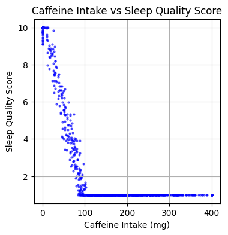

```python
plt.figure(figsize=(4, 4))
plt.scatter(df_caffeine_sleep['Caffeine_Intake_mg'], df_caffeine_sleep['Sleep_Quality_Score'], color='blue', alpha=0.6, s = 4)
plt.title('Caffeine Intake vs Sleep Quality Score')
plt.xlabel('Caffeine Intake (mg)')
plt.ylabel('Sleep Quality Score')
plt.grid(True)
plt.show()
```

There appears to be a linear relationship between Caffeine Intake(mg) and Sleep Quality Score, but after more than around 100mg of caffeine the only possible Sleep Score is 1 (the lowest score).

To accomodate this elbow in the data, we will be cutting our dataframe after the value of Caffeine Intake that doesn't yield a sleep score greater than 1.

```python
# Find the maximum value of 'Caffeine_Intake_mg' where 'Sleep_Quality_Score' is not equal to 1
max_caffeine = df_caffeine_sleep[df_caffeine_sleep['Sleep_Quality_Score'] != 1]['Caffeine_Intake_mg'].max()
max_caffeine
```

```
101.7686429063697
```

For our analysis, we will restrict our focus to Caffeine Intake values below 102, based on the calculated threshold.

```python
# Getting only entries with less than 100 mg caffeine
df_new = df_caffeine_sleep[df_caffeine_sleep['Caffeine_Intake_mg'] < 102].copy()
```

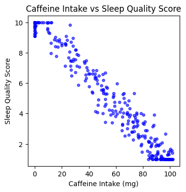

```python
plt.figure(figsize=(4, 4))
plt.scatter(df_new['Caffeine_Intake_mg'], df_new['Sleep_Quality_Score'], color='blue', alpha=0.6, s = 15)
plt.title('Caffeine Intake vs Sleep Quality Score')
plt.xlabel('Caffeine Intake (mg)')
plt.ylabel('Sleep Quality Score')
plt.show()
```

Now it is clear there is a **strong, negative, linear relationship** between Caffeine Intake and Sleep Quality Score.

### 2. Descriptive Statistics

```python
df_new.describe()
```

|  | Caffeine_Intake_mg | Sleep_Quality_Score |
| --- | --- | --- |
| count | 336.000000 | 336.000000 |
| mean | 46.825162 | 5.740910 |
| std | 36.270611 | 3.391827 |
| min | 0.000000 | 1.000000 |
| 25% | 2.749610 | 2.516332 |
| 50% | 50.174048 | 5.502730 |
| 75% | 81.345105 | 9.660561 |
| max | 101.935206 | 10.000000 |

### 3. Correlation Coefficient

```python
# Calculate the correlation coefficient
correlation = df_new['Caffeine_Intake_mg'].corr(df_new['Sleep_Quality_Score'])
print(f"Correlation coefficient: {correlation}")
```

```
Correlation coefficient: -0.9824402409760141
```

We computed a coefficient of **-0.98**. Because this is very close to -1, it indicates that there is a **very strong, negative, linear relationshp**, suggesting that caffeine intake is highly predicitve of sleep quality.

### 4. Histograms

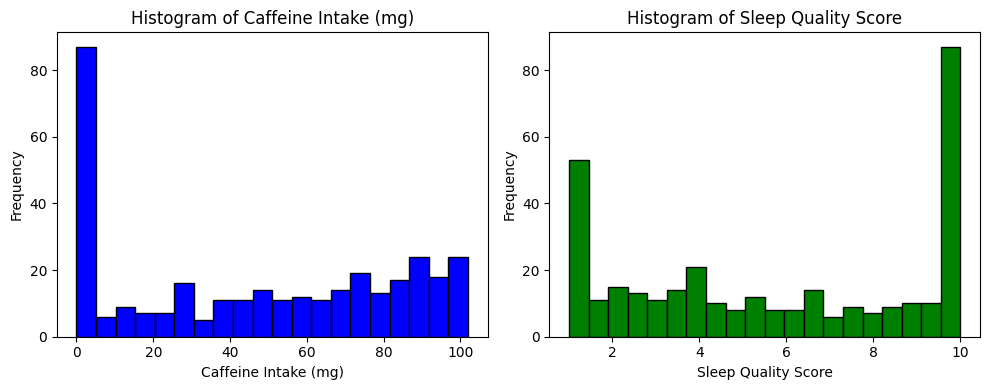

```python
# Plot histogram for Caffeine_Intake_mg
plt.figure(figsize=(10, 4))

# Subplot for Caffeine Intake
plt.subplot(1, 2, 1)
plt.hist(df_new['Caffeine_Intake_mg'], bins=20, color='blue', edgecolor='black')
plt.title('Histogram of Caffeine Intake (mg)')
plt.xlabel('Caffeine Intake (mg)')
plt.ylabel('Frequency')

# Subplot for Sleep Quality Score
plt.subplot(1, 2, 2)
plt.hist(df_new['Sleep_Quality_Score'], bins=20, color='green', edgecolor='black')
plt.title('Histogram of Sleep Quality Score')
plt.xlabel('Sleep Quality Score')
plt.ylabel('Frequency')

# Display the plot
plt.tight_layout()
plt.show()
```

These definitely don't have a normal distribution. With caffeine, we can see that a large number of people don't drink coffee. It slowly starts rising as caffeine intake increases. Sleep quality has spikes with 10 and 1. The scores in between seem to stay around the same frequency

### EDA Conclusion

After the exploratory data analysis we can see that there is a **strong, negative, linear assocation** between Caffeine Intake and Sleep Quality Score. This is backed by the correlation coefficent of -0.98 and the scatterplots. However, there appears to be clustered points towards the ends of High sleep quality score and Low Caffeine Intake. We can now move on to modeling our data with Simple Linear Regression

## Simple Linear Regression

Simple Linear Regression models the relationship between two variables. We can predict the value of a dependent variable based on the value of an independent variable. In our data, we are interested in predicted Sleep Quality Score based on Caffeine Intake (in mg). We hope to get an equation like this:

$\hat{\text{Sleep Quality Score}}_i = \hat{\beta_0} + \hat{\beta_1} (\text{Caffeine Intake}_i)$

```python
#fitting an OLS model
y = df_new['Sleep_Quality_Score']  # Dependent variable
X = sm.add_constant(df_new['Caffeine_Intake_mg'])  # Independent variable with constant added
mod = sm.OLS(y, X)  # Ordinary Least Squares model
res = mod.fit()  # Fit the model
res.summary()
```

OLS Regression Results

| Dep. Variable: | Sleep_Quality_Score | R-squared: | 0.965 |
| --- | --- | --- | --- |
| Model: | OLS | Adj. R-squared: | 0.965 |
| Method: | Least Squares | F-statistic: | 9261. |
| Date: | Thu, 26 Sep 2024 | Prob (F-statistic): | 1.30e-245 |
| Time: | 23:15:39 | Log-Likelihood: | -322.53 |
| No. Observations: | 336 | AIC: | 649.1 |
| Df Residuals: | 334 | BIC: | 656.7 |
| Df Model: | 1 |  |  |
| Covariance Type: | nonrobust |  |  |

|  | coef | std err | t | P>\|t\| | [0.025 | 0.975] |
| --- | --- | --- | --- | --- | --- | --- |
| const | 10.0428 | 0.057 | 177.703 | 0.000 | 9.932 | 10.154 |
| Caffeine_Intake_mg | -0.0919 | 0.001 | -96.232 | 0.000 | -0.094 | -0.090 |

| Omnibus: | 6.655 | Durbin-Watson: | 2.100 |
| --- | --- | --- | --- |
| Prob(Omnibus): | 0.036 | Jarque-Bera (JB): | 8.605 |
| Skew: | 0.159 | Prob(JB): | 0.0135 |
| Kurtosis: | 3.717 | Cond. No. | 96.8 |

Notes:  
[1] Standard Errors assume that the covariance matrix of the errors is correctly specified.

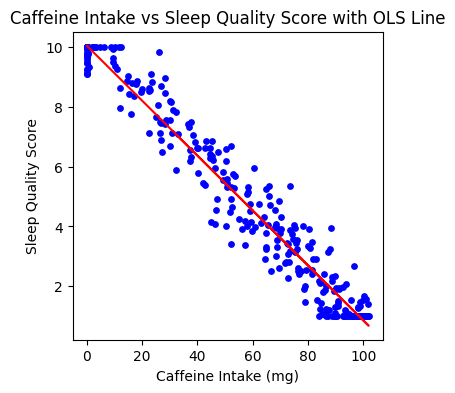

```python
plt.figure(figsize=(4, 4))
plt.scatter(df_new['Caffeine_Intake_mg'], df_new['Sleep_Quality_Score'], color='blue', label='Data points', s=15)

predicted_values = res.predict(X)
plt.plot(df_new['Caffeine_Intake_mg'], predicted_values, color='red', label='OLS Regression Line')

# Adding labels and title
plt.title('Caffeine Intake vs Sleep Quality Score with OLS Line')
plt.xlabel('Caffeine Intake (mg)')
plt.ylabel('Sleep Quality Score')
plt.show()
```

Althought the model looks good, before we can use our linear regression model for conclusions, we must make sure we all assumptions are met. Ensuring these assumptions are met is important because violations can lead to inaccurate or misleading results.

```python
#Save residuals and fitted values to the dataframe
df_new.loc[:, 'fitted_values'] = res.fittedvalues  # Save fitted values
df_new.loc[:, 'residuals'] = res.resid  # Save residuals
df_new.head()
```

|  | Caffeine_Intake_mg | Sleep_Quality_Score | fitted_values | residuals |
| --- | --- | --- | --- | --- |
| 2 | 0.000000 | 10.000000 | 10.042849 | -0.042849 |
| 5 | 22.576788 | 7.122153 | 7.968666 | -0.846513 |
| 8 | 76.576668 | 2.409237 | 3.007569 | -0.598332 |
| 15 | 98.823644 | 1.485861 | 0.963686 | 0.522175 |
| 16 | 0.000000 | 9.080636 | 10.042849 | -0.962212 |

# Assumptions

## Are the residuals independant?

```python
from statsmodels.stats.stattools import durbin_watson
durbin_watson_stat = durbin_watson(res.resid)
print("Durbin-Watson Test statistic:",durbin_watson_stat)
```

```
Durbin-Watson Test statistic: 2.099879556284351
```

## Are any additional predictor variables required?

```python
print(f"R-squared:\t\t{res.rsquared:.3f}")
print(f"Adjusted R-squared:\t{res.rsquared_adj:.3f}")
```

```
R-squared:		0.965
Adjusted R-squared:	0.965
```

## Is X v Y Linear?

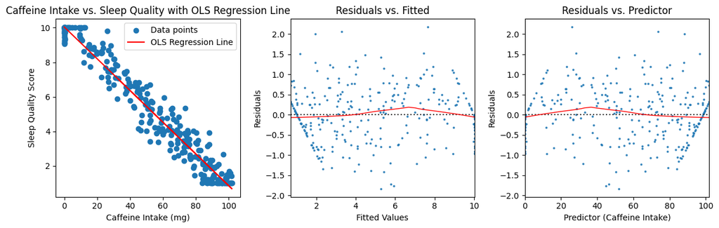

```python
fig, axes = plt.subplots(1, 3, figsize=(12, 4))

# Scatter plot
axes[0].scatter(df_new['Caffeine_Intake_mg'], df_new['Sleep_Quality_Score'], label='Data points')
axes[0].plot(df_new['Caffeine_Intake_mg'], df_new['fitted_values'], color='red', label='OLS Regression Line')
axes[0].set_xlabel('Caffeine Intake (mg)')
axes[0].set_ylabel('Sleep Quality Score')
axes[0].set_title('Caffeine Intake vs. Sleep Quality with OLS Regression Line')
axes[0].legend()

# Residuals vs Fitted plot
sns.residplot(x=df_new['fitted_values'],
               y=df_new['residuals'],
               lowess=True,
               scatter_kws={'s': 3},
               line_kws={'color': 'red', 'lw': 1},
               ax=axes[1])  # Specify the first axis
axes[1].set_title("Residuals vs. Fitted")
axes[1].set_ylabel("Residuals")
axes[1].set_xlabel("Fitted Values")

# Residuals vs Predictor Plot
sns.residplot(x=df_new['Caffeine_Intake_mg'],
               y=df_new['residuals'],
               lowess=True,
               scatter_kws={'s': 3},
               line_kws={'color': 'red', 'lw': 1},
               ax=axes[2])
axes[2].set_ylabel("Residuals")
axes[2].set_xlabel("Predictor (Caffeine Intake)")
axes[2].set_title("Residuals vs. Predictor")

# Show the plots
plt.tight_layout()
plt.show()
```

The scatterplot for Caffeine Intake vs Sleep Quality is mostly linear. When we look at the residuals vs fitted and the residuals vs predictor plots, both nearly have a straight line (there are slight bumps but nothing of concern, its still mostly linear). Therefore, the assumption that Caffeine Intake vs Sleep Quality is linear **is met.**

## Are the residuals normally distributed?

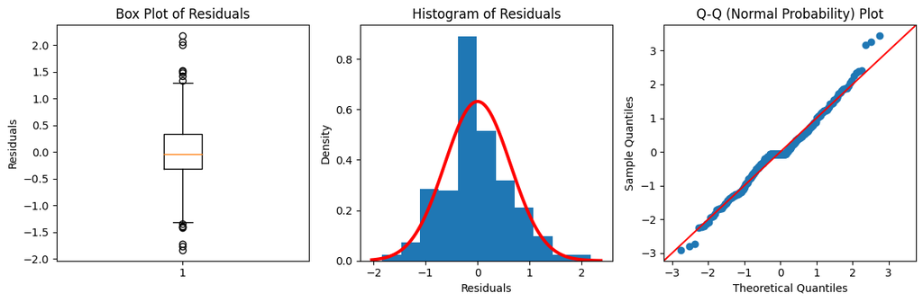

```python
fig, axes = plt.subplots(1, 3, figsize=(12, 4))

# Box plot
axes[0].boxplot(df_new['residuals'])
axes[0].set_ylabel("Residuals")
axes[0].set_title("Box Plot of Residuals")

# Histogram
axes[1].hist(df_new['residuals'],
             density=True,
             bins=11)
axes[1].set_xlabel("Residuals")
axes[1].set_ylabel("Density")

mean = np.mean(df_new['residuals'])
sd = np.std(df_new['residuals'])
xmin, xmax = axes[1].get_xlim()
x = np.linspace(xmin, xmax, 100)

axes[1].plot(x,
             stat.norm.pdf(x, mean, sd),
             color='r',
             lw=3)
axes[1].set_title("Histogram of Residuals")

# Q-Q (Normal Probability) Plot
sm.qqplot(df_new['residuals'],
           line='45',
           fit=True,
           ax=axes[2])
axes[2].set_title("Q-Q (Normal Probability) Plot")

# Show the plots
plt.tight_layout()
plt.show()
```

```python
stat.shapiro(df_new['residuals'])
```

```
ShapiroResult(statistic=0.9827301335525679, pvalue=0.00046293869911718285)
```

- **Box Plot:** When we look at the Box plot, it appears to be normal. There may be some outliers, but the spread seems normal with the mean centered close to 0.
- **Histogram:** The histogram also appears normal, although there does appear to be a very high density close to 0.
- **Q-Q Plot:** The Q-Q plot has most points close to the red line indicating normality.
- **Shapiro-Wilk:** When we look at the Shapiro-Wilk results, the p-value is super small, less than 0.05, which means the null hypothesis that the residuals are normally distibuted. This is fine because the Shapiro-Wilk test is easily influenced by outliers, which could explain it being low.

Based on the first 3 graphs, the assumption that the residuals are normally distributed **is met.**

## Do the residuals have constant variance?

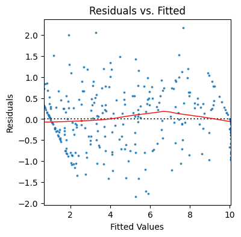

```python
# Residuals vs. Fitted Values Plot
fig = plt.figure(figsize = (4, 4))
sns.residplot(x = df_new['fitted_values'],
              y = df_new['residuals'],
              lowess = True,
              scatter_kws = {'s': 3},
              line_kws = {'color': 'red', 'lw': 1})
plt.title("Residuals vs. Fitted")
plt.ylabel("Residuals")
plt.xlabel("Fitted Values")
plt.show()
```

Based on the Residuals vs Fitted Values plot, the residuals appear to have constant variance. From values 0-10, the variance remains the same, so the assumption of homoscedasticity **is met.**

## Are there any influential points?

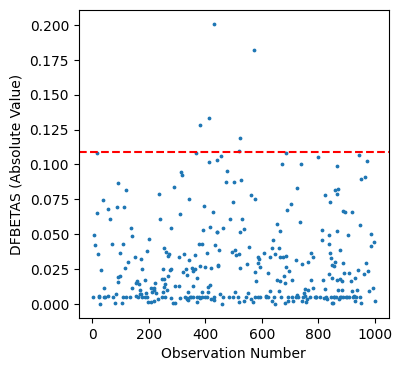

|  | Caffeine_Intake_mg | Sleep_Quality_Score | fitted_values | residuals | dfbetas |
| --- | --- | --- | --- | --- | --- |
| 431 | 88.278775 | 3.930044 | 1.932468 | 1.997576 | 0.200906 |
| 571 | 96.690960 | 2.670970 | 1.159621 | 1.511349 | 0.181977 |
| 412 | 73.581321 | 5.343534 | 3.282758 | 2.060776 | 0.133599 |
| 381 | 88.022787 | 3.247871 | 1.955986 | 1.291884 | 0.127979 |
| 518 | 26.043771 | 9.824206 | 7.650146 | 2.174060 | -0.109602 |
| 521 | 83.845856 | 1.000000 | 2.339731 | -1.339731 | -0.119230 |

```python
# DFBETAS
df_new['dfbetas'] = res.get_influence().dfbetas[:, 1]

fig = plt.figure(figsize = (4, 4))
plt.ylabel("DFBETAS (Absolute Value)")
plt.xlabel("Observation Number")
plt.scatter(df_new.index,
            np.abs(df_new['dfbetas']),
            s = 3)
plt.axhline(y = 2 / np.sqrt(len(df_new)),
            color = 'r',
            linestyle = 'dashed')
plt.show()

# OPTIONAL: code to grab info about potential influential points
outliers_dfbetas = df_new[np.abs(df_new['dfbetas']) > 2 / np.sqrt(len(df_new))]
outliers_dfbetas_sorted = outliers_dfbetas.sort_values(by = 'dfbetas',
                                                       ascending = False)
outliers_dfbetas_sorted
```

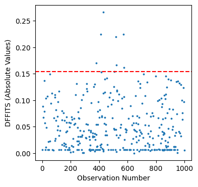

|  | Caffeine_Intake_mg | Sleep_Quality_Score | fitted_values | residuals | dfbetas | dffits |
| --- | --- | --- | --- | --- | --- | --- |
| 431 | 88.278775 | 3.930044 | 1.932468 | 1.997576 | 0.200906 | 0.266782 |
| 571 | 96.690960 | 2.670970 | 1.159621 | 1.511349 | 0.181977 | 0.224909 |
| 412 | 73.581321 | 5.343534 | 3.282758 | 2.060776 | 0.133599 | 0.224835 |
| 518 | 26.043771 | 9.824206 | 7.650146 | 2.174060 | -0.109602 | 0.220219 |
| 381 | 88.022787 | 3.247871 | 1.955986 | 1.291884 | 0.127979 | 0.170399 |
| 574 | 52.007443 | 3.427310 | 5.264802 | -1.837491 | -0.022959 | -0.162083 |
| 521 | 83.845856 | 1.000000 | 2.339731 | -1.339731 | -0.119230 | -0.166796 |

```python
# DFFITS
df_new['dffits'] = res.get_influence().dffits[0]

fig = plt.figure(figsize = (4, 4))
plt.ylabel("DFFITS (Absolute Values)")
plt.xlabel("Observation Number")
plt.scatter(df_new.index,
            np.abs(df_new['dffits']),
            s = 3)
plt.axhline(y = 2 * np.sqrt(len(res.params) / len(df_new)),
            color = 'r',
            linestyle = 'dashed')
plt.show()

# OPTIONAL: code to grab info about potential influential points
outliers_dffits = df_new[np.abs(df_new['dffits']) > 2 * np.sqrt(len(res.params) / len(df_new))]
outliers_dffits_sorted = outliers_dffits.sort_values(by = 'dffits',
                                                     ascending = False)
outliers_dffits_sorted
```

Looking at the DFBETAS and DFFITS plots, most data points fall within acceptable ranges indicating that individual observations are not excessively influencing the overall model. However, there are approximately six points that lie above the red threshold line which suggest some level of influence on the regression results. While these points do not currently pose a significant concern, they can be monitored in the rest of the analysis to ensure they do not disproportionately affect the model's conclusions, but ultimately the assumption that there are no influential points **is met.**

# Transformation

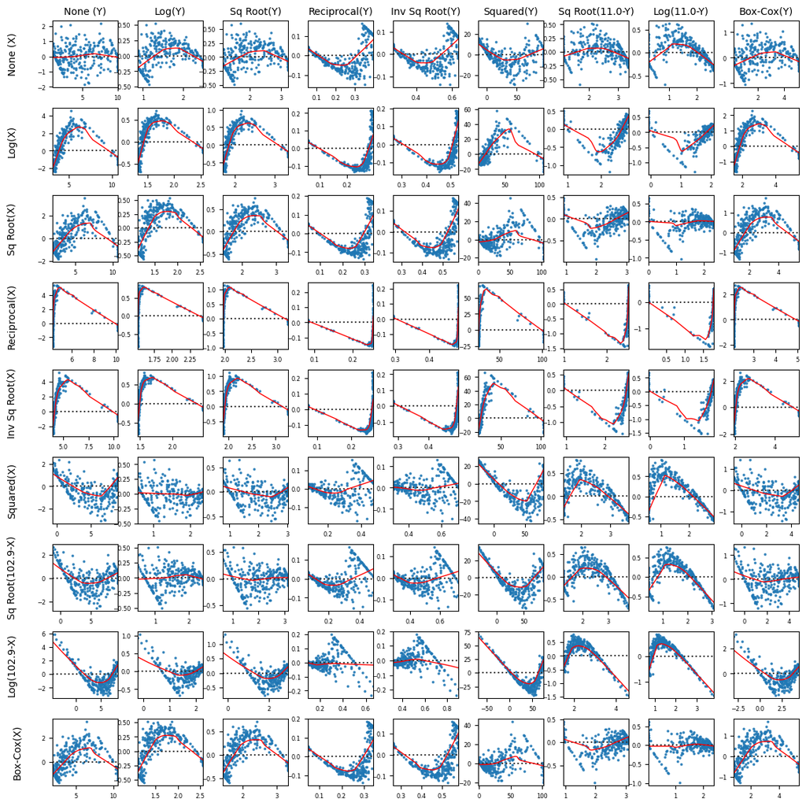

```python
# @title
import numpy as np
import pandas as pd
import matplotlib.pyplot as plt
import seaborn as sns
import statsmodels.api as sm
from scipy.stats import boxcox
from sklearn.preprocessing import power_transform

# Existing transformations
df_new['Caffeine_sqrt_trans'] = np.sqrt(df_new['Caffeine_Intake_mg'])
df_new['Caffeine_log_trans'] = np.log(df_new['Caffeine_Intake_mg'] + 1)  # Add 1 to avoid log(0)
df_new['Caffeine_reciprocal_trans'] = 1 / (df_new['Caffeine_Intake_mg'] + 1)  # Add 1 to avoid division by 0

df_new['Sleep_sqrt_trans'] = np.sqrt(df_new['Sleep_Quality_Score'])
df_new['Sleep_log_trans'] = np.log(df_new['Sleep_Quality_Score'] + 1)  # Add 1 to avoid log(0)
df_new['Sleep_reciprocal_trans'] = 1 / (df_new['Sleep_Quality_Score'] + 1)  # Add 1 to avoid division by 0

# Box-Cox transformation (requires all values to be positive)
df_new['Caffeine_BoxCox'], caffeine_lambda = boxcox(df_new['Caffeine_Intake_mg'] + 1)  # Adding 1 to avoid zero values
df_new['Sleep_BoxCox'], sleep_lambda = boxcox(df_new['Sleep_Quality_Score'])

# New transformations: 1/sqrt(X), X^2, sqrt(constant - X), log(constant - X)
df_new['Caffeine_inverse_sqrt_trans'] = 1 / np.sqrt(df_new['Caffeine_Intake_mg'] + 1)  # Add 1 to avoid sqrt(0)
df_new['Caffeine_squared_trans'] = df_new['Caffeine_Intake_mg'] ** 2

df_new['Sleep_inverse_sqrt_trans'] = 1 / np.sqrt(df_new['Sleep_Quality_Score'] + 1)  # Add 1 to avoid sqrt(0)
df_new['Sleep_squared_trans'] = df_new['Sleep_Quality_Score'] ** 2

# sqrt(constant - X) and log(constant - X)
constant_x = df_new['Caffeine_Intake_mg'].max() + 1  # Add a margin to avoid negative values
constant_y = df_new['Sleep_Quality_Score'].max() + 1

df_new['Caffeine_sqrt_constant_minus'] = np.sqrt(constant_x - df_new['Caffeine_Intake_mg'])
df_new['Caffeine_log_constant_minus'] = np.log(constant_x - df_new['Caffeine_Intake_mg'])

df_new['Sleep_sqrt_constant_minus'] = np.sqrt(constant_y - df_new['Sleep_Quality_Score'])
df_new['Sleep_log_constant_minus'] = np.log(constant_y - df_new['Sleep_Quality_Score'])

# Update transformation lists
x_transformations = [
    ('Caffeine_Intake_mg', 'None (X)'),
    ('Caffeine_log_trans', 'Log(X)'),
    ('Caffeine_sqrt_trans', 'Sq Root(X)'),
    ('Caffeine_reciprocal_trans', 'Reciprocal(X)'),
    ('Caffeine_inverse_sqrt_trans', 'Inv Sq Root(X)'),
    ('Caffeine_squared_trans', 'Squared(X)'),
    ('Caffeine_sqrt_constant_minus', 'Sq Root('+str(round(constant_x,1))+'-X)'),
    ('Caffeine_log_constant_minus', 'Log('+str(round(constant_x,1))+'-X)'),
    ('Caffeine_BoxCox', 'Box-Cox(X)'),
]

y_transformations = [
    ('Sleep_Quality_Score', 'None (Y)'),
    ('Sleep_log_trans', 'Log(Y)'),
    ('Sleep_sqrt_trans', 'Sq Root(Y)'),
    ('Sleep_reciprocal_trans', 'Reciprocal(Y)'),
    ('Sleep_inverse_sqrt_trans', 'Inv Sq Root(Y)'),
    ('Sleep_squared_trans', 'Squared(Y)'),
    ('Sleep_sqrt_constant_minus', 'Sq Root('+str(round(constant_y,1))+'-Y)'),
    ('Sleep_log_constant_minus', 'Log('+str(round(constant_y,1))+'-Y)'),
    ('Sleep_BoxCox', 'Box-Cox(Y)'),
]




# Function to create residual vs fitted value plots matrix
def plot_residuals_matrix(df_new):
    fig, axes = plt.subplots(len(x_transformations), len(y_transformations), figsize=(12, 12))

    for i, (x_col, x_label) in enumerate(x_transformations):
        for j, (y_col, y_label) in enumerate(y_transformations):
            X = df_new[x_col]
            y = df_new[y_col]

            try:
                # Fit OLS model
                X_const = sm.add_constant(X)
                model = sm.OLS(y, X_const).fit()

                # Plot residuals vs fitted values
                sns.residplot(x=model.fittedvalues, y=model.resid, lowess=True,
                              ax=axes[i, j], scatter_kws={'s': 3}, line_kws={'color': 'red', 'lw': 1})

                # Remove individual titles and labels for compactness
                axes[i, j].set_xlabel('')
                axes[i, j].set_ylabel('')
                axes[i, j].tick_params(axis='both', which='major', labelsize=6)

            except Exception as e:
                print(f"Error fitting model for {x_col} and {y_col}: {e}")

    # Set row and column labels outside the plot area
    for ax, col in zip(axes[0], [y_label for _, y_label in y_transformations]):
        ax.set_title(col, size=10)

    for ax, row in zip(axes[:, 0], [x_label for _, x_label in x_transformations]):
        ax.set_ylabel(row, rotation=90, size=10, labelpad=20)

    plt.tight_layout(pad=3)
    plt.subplots_adjust(hspace=0.3, wspace=0.3)  # Adjust spacing
    plt.show()

# Call the function to create the matrix of residuals vs. fitted values plots
plot_residuals_matrix(df_new)
```

After running through all 6 assumptions necessary for a Simple Linear Regression model, all were met. But,when looking at if the residuals were normally distributed, we did find that the Shapiro-Wilk test yielded unsatisfactory results. To combat this, various transformations were tested to see if all other assumptions could still be met while the residuals became more-normally distributed. Ultimately, as seen above, no transformations had satisfactory residuals vs. fitted values plots so the untransformed data will be used for the analysis.

# Model Assessment

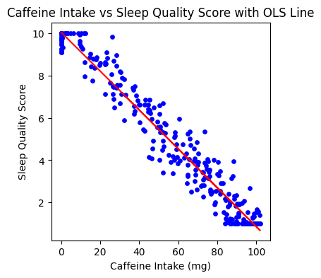

```python
# Scatter plot of the original data
plt.figure(figsize=(4, 4))
plt.scatter(df_new['Caffeine_Intake_mg'], df_new['Sleep_Quality_Score'], color='blue', label='Data points', s=15)

predicted_values = res.predict(X)
plt.plot(df_new['Caffeine_Intake_mg'], predicted_values, color='red', label='OLS Regression Line')

# Adding labels and title
plt.title('Caffeine Intake vs Sleep Quality Score with OLS Line')
plt.xlabel('Caffeine Intake (mg)')
plt.ylabel('Sleep Quality Score')
plt.show()
```

Now that we have our model, we can begin evaluating it. By assessing how well the model fits the data and ensuring the residuals behave appropriately, we can determine the reliability and generalizability of the model's predictions. The goal is to confirm that the model provides accurate, unbiased estimates and is suitable for making informed predictions or decisions based on the data.

### $R^2$ & Adjusted $R^2$

```python
print(f"R-squared:\t\t{res.rsquared:.5f}")
print(f"Adjusted R-squared:\t{res.rsquared_adj:.5f}")
```

```
R-squared:		0.96519
Adjusted R-squared:	0.96508
```

When evaluating $ R^2 $ or Adjusted $ R^2 $, higher values generally indicate a better fit for the model. In this case, both $ R^2 $ and Adjusted $ R^2 $ are 0.965, meaning that 96.5% of the variation in sleep quality scores can be explained by caffeine intake. This suggests that the model fits the data well, and caffeine intake is a strong predictor of sleep quality; there aren't other variables that are influencing our Sleep Score observations, it's mostly the Caffeine Intake variable.

### F test

```python
print("The test statistic for the F-test is ",
      round(res.fvalue, 2),
      "\nand the corresponding p-value is ",
      res.f_pvalue)
```

```
The test statistic for the F-test is  9260.62
and the corresponding p-value is  1.3013815196237135e-245
```

- **F-Statistic:** The F-statistic is used to test the overall significance of the regression model by comparing the model with no predictors--a model that only includes the intercept--to the model with caffeine intake as a predictor.The F-statistic of 9260.6 is very large, which indicates that the variance explained by your model is much larger than the unexplained variance. A large F-statistic suggests that the regression model is significantly better at predicting the Sleep ScoreCaffeine Intake significantly improves the model's ability to predict the Sleep Score than a model that only predicts the mean value of the sleep score.
- **P-Value:** The p-value represents the probability that the observed relationship between the variables, Caffeine Intake and Sleep Quality Score, could have occurred purely by random chance, assuming that there is no true relationship between them (the null hypothesis). In our case, the p-value is extremely small which means there is an almost nonexistent chance that the relationship observed in the data is due to random chance. Therefore we can reject the null hypothesis and accept that Caffeine Intake is a statistically significant predictor of Sleep Quality.

### RMSE

```python
rmse = np.sqrt(np.sum((df_new['Sleep_Quality_Score'] - df_new['fitted_values']) ** 2) / (len(df_new) - 2))
print("RMSE:",rmse)
```

```
RMSE: 0.6337853035537434
```

The RMSE represents the average amount of spread in the residuals. The RMSE indicates that the average error in our model is around 0.63 Sleep Quality Points. Since the observed number of points ranges from about 1 to 10, an error of 0.63 boxes is small. Overall, this value is relatively close to 0 and is low relative to the scale of Y, which indicates that Caffeine Intake is very useful at predicting Sleep Quality Score

### MAE

```python
mae = np.sum(np.abs(df_new['Sleep_Quality_Score'] - df_new['fitted_values'])) / (len(df_new) - 2)
print("MAE:",mae)
```

```
MAE: 0.46840941591128055
```

The MAE represents the average magnitude of the residuals, or the average absolute difference between the observed and predicted values. In this case, the MAE indicates that the average error in our model is approximately 0.47 Sleep Quality Points. Since the observed number of points ranges from 1 to 10, an error of 0.47 points is relatively small. This suggests that our models predictions are quite accurate. Overall, the MAE is close to 0 and low relative to the scale of the Sleep Quality Score, indicating that Caffeine Intake is a useful predictor of Sleep Quality Score.

## Model Assessment Conclusion

The linear regression model demonstrates strong predictive performance for Sleep Quality Score based on Caffeine Intake. The MAE of 0.47 and RMSE of 0.63 indicate small average errors, showing that the model makes accurate predictions. The F-test statistic of 9260.62 with a p-value close to zero confirms the statistical significance of the model, while the R-squared value of 0.96519 and Adjusted R-squared of 0.96508 show that the model explains approximately 96.5% of the variance in sleep quality. Overall, the model fits the data well and confirms that Caffeine Intake is a strong predictor of Sleep Quality Score.

# Statistical Inference

Statistical inference is crucial in our analysis because it allows us to draw conclusions about a population based on a sample of data. Instead of simply describing the data at hand, statistical inference helps us determine whether the relationships we observe—such as the link between caffeine intake and sleep quality—are likely to exist in the broader population or if they could have arisen by random chance. Through methods like hypothesis testing and confidence intervals, we assess the significance, strength, and reliability of the model. For example, the p-value helps us determine whether caffeine intake is a significant predictor of sleep quality, while confidence intervals provide a range for the true effect size.

### Confidence Interval for Slope ($\beta_1$)

```python
slope_conf_int = res.conf_int().iloc[1]
print("Confidence Interval: (",slope_conf_int.iloc[0],", ",slope_conf_int.iloc[1],")", sep = "")
```

```
Confidence Interval: (-0.09375034855590095, -0.08999440070908135)
```

The confidence interval represents the range within which the true value of the coefficient $ \beta_1 $ is expected to lie with a certain level of confidence, 95% in for our test. The fact that the interval does not include 0 confirms that the effect of caffeine intake on sleep quality is significant and there is strong evidence that caffeine intake has a negative effect on sleep quality, rather than no effect.

As caffeine intake increases by 1 mg, we are 95% confident that the Sleep Quality Score will decrease by a value between -0.0938 and -0.0900 units.

### Hypothesis Test For Slope ($\beta_1$)

```python
# Extract the t-statistic and p-value for the slope (β1)
slope_t_stat = res.tvalues.iloc[1]
slope_p_value = res.pvalues.iloc[1]

# Print the test statistic and p-value
print(f"Test statistic for the slope:\t{slope_t_stat}")
print(f"P-value for the slope:\t\t{slope_p_value}")
```

```
Test statistic for the slope:	-96.23211882820712
P-value for the slope:		1.301381519623804e-245
```

The test statistic measures how many standard errors the estimated slope is away from zero. The test statistic of -96.23 is extremely large in absolute value, indicating that the slope of the relationship between caffeine intake and sleep quality score is far from zero.

The p-value represents the chance that the observed relationship between the variables Caffeine Intake and Sleep Quality could have occurred purely by random chance, assuming that there is no true relationship between them (the null hypothesis). Since the p-value is much smaller than any conventional significance level like 0.05 or 0.01, we reject the null hypothesis that there is no relationship between Caffeine Intake and Sleep Quality. This means that caffeine intake is highly statistically significant in predicting sleep quality.

### Confidence Interval For The Mean of Y

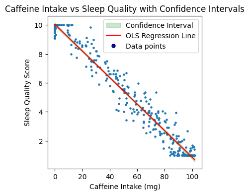

```python
# Define Caffeine Intake values to predict (200 evenly spaced values between min and max caffeine intake)
x = np.linspace(min(df_new['Caffeine_Intake_mg']), max(df_new['Caffeine_Intake_mg']), num=200)
X = sm.add_constant(x)  # Add intercept for predictions

# Predict and store results with confidence intervals
pred_trans = res.get_prediction(X).summary_frame(alpha=0.05)  # 95% Confidence intervals

# Plot the predictions
plt.figure(figsize=(4, 4))
plt.scatter(df_new['Caffeine_Intake_mg'], df_new['Sleep_Quality_Score'], label='Data points', s=5)
plt.plot(x, pred_trans['mean'], color='red', label='OLS Regression Line')

# Fill the area between the confidence intervals (Make the band green)
plt.fill_between(x,
                 pred_trans['mean_ci_lower'],
                 pred_trans['mean_ci_upper'],
                 color='green',
                 alpha=0.2)

# Create a custom legend entry for the confidence interval
confidence_interval_patch = mpatches.Patch(color='green', alpha=0.2, label='Confidence Interval')

# Labels and title
plt.xlabel('Caffeine Intake (mg)')
plt.ylabel('Sleep Quality Score')
plt.title('Caffeine Intake vs Sleep Quality with Confidence Intervals')

# Add the custom patch to the legend
plt.legend(handles=[confidence_interval_patch, plt.Line2D([], [], color='red', label='OLS Regression Line'),
                    plt.Line2D([], [], marker='o', color='none', markerfacecolor='blue', markersize=5, label='Data points')])

plt.show()
```

With the confidence interval band plotted on the graph, we can see just how tight it fits to the OLS Regression line. Now we will look at an example value for this band.

The average caffeine in a shot of espresso is 63 mg; we will do a confidence Interval for the Y (Sleep Score) when X (Caffeine Intake) is 63mg as an example.

```python
ex_caffeine = 63
pred = res.get_prediction([1, ex_caffeine])
ci_mean = pred.summary_frame(alpha=0.05).loc[:, ['mean_ci_lower', 'mean_ci_upper']]
print("Confidence Interval for ", ex_caffeine,"mg of Caffeine: (",ci_mean.iloc[0].loc['mean_ci_lower'],", ",ci_mean.iloc[0].loc['mean_ci_upper'],")", sep = "")
```

```
Confidence Interval for 63mg of Caffeine: (4.180400515131833, 4.329378056752002)
```

We are 95% confident that the average Sleep Quality Score points is between 4.18 and 4.32 when the amount of Caffeine Intake is 63 mg (or 1 shot of Espresso).

### Prediction Interval For an Individual Observation

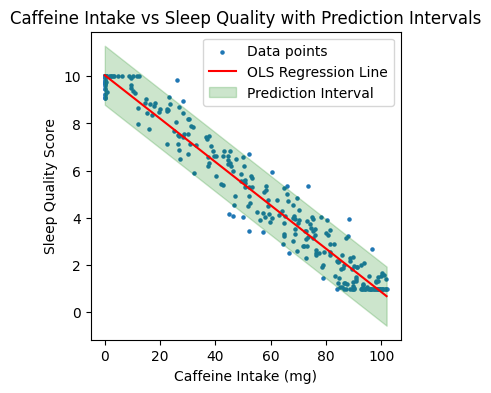

```python
# Plot the predictions
plt.figure(figsize=(4, 4))
plt.scatter(df_new['Caffeine_Intake_mg'], df_new['Sleep_Quality_Score'], label='Data points', s = 5)
plt.plot(x, pred_trans['mean'], color='red', label='OLS Regression Line')

# Fill the area between the prediction intervals
plt.fill_between(x,
                 pred_trans['obs_ci_lower'],  # Lower prediction interval
                 pred_trans['obs_ci_upper'],  # Upper prediction interval
                 color='green',
                 alpha=0.2,
                 label='Prediction Interval')

# Labels and title
plt.xlabel('Caffeine Intake (mg)')
plt.ylabel('Sleep Quality Score')
plt.title('Caffeine Intake vs Sleep Quality with Prediction Intervals')
plt.legend()

# Show the plot
plt.show()
```

Now, looking at the catter plot witht he prediction interval, it's relatively slim around the OLS line and encapsulates most of our data. Given that it aims to include 95% of observations, the interval looks like a great fit. Once again, we will use 63 mg as example to do a prediction interval for Y (Sleep Score) when X (Caffeine Intake) is 63 mg.

```python
ci_pred = pred.summary_frame(alpha=0.05).loc[:, ['obs_ci_lower', 'obs_ci_upper']]
print("Prediction Interval for ", ex_caffeine,"mg of Caffeine: (",ci_pred.iloc[0].loc['obs_ci_lower'],", ",ci_pred.iloc[0].loc['obs_ci_upper'],")", sep = "")
```

```
Prediction Interval for 63mg of Caffeine: (3.0059520108889584, 5.503826560994877)
```

We are 95% confident that Sleep Quality Score is between 3.01 and 5.50 when the amount of Caffeine consumed is 63 mg (or 1 shot of Espresso).

# Conclusion

Throughout this project, we analyzed the Comprehensive Sleep and Health Metrics dataset. The dataset was designed to simulate a wide range of factors influencing sleep quality. The primary object of our anlysis was to explore the relationship between caffeine intake and sleep quality and to develop a predictive model based on these factors.

We used simple linear regression to model (using Ordinary Least Squares, OLS) the relationship between Caffeine Intake and Sleep Quality Score. The analysis revealed a strong negative linear relationship, indicating that as caffeine intake increases, sleep quality significantly decreases. We ran some assessments to test our model that indicated positive results in favor of our model. We got an R-squared value of 0.96519, confirming the effectiveness of caffeine intake as a predictor of sleep quality. Low RMSE(0.63) and MAE(0.47) scores further demonstrated that the model's predictions were accurate with minimal error relative to the scale of the data. The small p-value associated with the slope of the regression confirms that this relationship is unlikely due to random chance.

To further solidify our conclusions, we calculated both the confidence interval and the prediction interval for our regression model. The confidence interval around the regression line shows a narrow range, demonstrating a high level of precision in our estimates for the mean sleep quality score given a specific level of caffeine intake. The prediction interval, which accounts for the uncertainty in predicting individual outcomes, is wider but still reasonable and to be expected, reinforcing that the model is effective for making predictions about new observations. These intervals give us confidence in the robustness of our conclusions, providing clear evidence that increasing caffeine intake reliably predicts a decrease in sleep quality.